# Characterising rocky intertidal biodiversity using environmental DNA metabarcoding from local to national scales

#### Shore position crossover

```r
pseq.rel.type <- subset_samples(pseq.rel, shorePosition != "NA")
shore <- unique(as.character(meta(pseq.rel.type)$shorePosition))

# supplying colors in the order they appear in list_core
mycols <- c("High"=highshore_colour,
            "Low"=lowshore_colour,
            "Open Water " = openwater_colour)

list_core <- c() # an empty object to store information

for (n in shore){ # for each variable n in primers
  print(paste0("Identifying Core Taxa for ", n))

  ps.sub <- subset_samples(pseq.rel.type, shorePosition == n) # Choose sample from DiseaseState by n

  core_m <- get_taxa_unique(prune_taxa(taxa_sums(ps.sub) > 0, ps.sub), "scientificname")

  print(paste0("No. of core taxa in ", n, " : ", length(core_m))) # print core taxa identified in each DiseaseState.
  list_core[[n]] <- core_m # add to a list core taxa for each group.
}
```

```
[1] "Identifying Core Taxa for High"
[1] "No. of core taxa in High : 602"
[1] "Identifying Core Taxa for Low"
[1] "No. of core taxa in Low : 659"
[1] "Identifying Core Taxa for Open Water"
[1] "No. of core taxa in Open Water : 854"
```

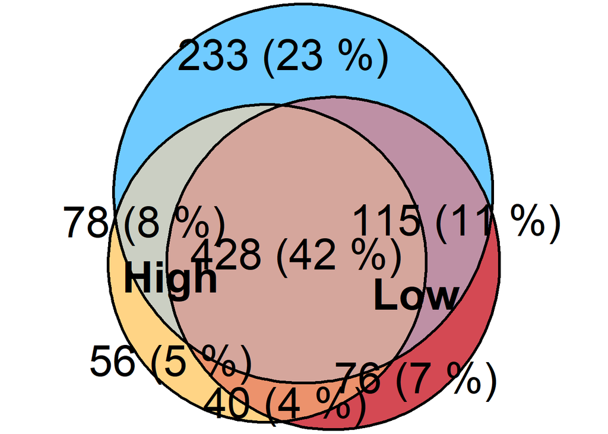

```r
venn_all_shore <- plot(euler(list_core),
                        fills = mycols,
                        shape = "ellipse",
                        quantities = list(type = c("counts", "percent"), cex = 3),
                        legend = FALSE,
                       labels = list(cex = 3, font = 2),
                       lwd = 3)

venn_all_shore
```

[figure not shown]

```r
venn_two <- cowplot::plot_grid(
  venn_all_primers,
  venn_all_shore,
  labels = c('a', 'b'),
  label_size = 50,
  nrow = 1
)

venn_two
```

```r
ggsave(filename = "Figures/venn_two.png", plot = venn_two,
       device = "png", dpi = 600, units = "mm", height = 550, width = 1250)
```

We can also look at crossover between regions, although the venn diagram is quite complex!

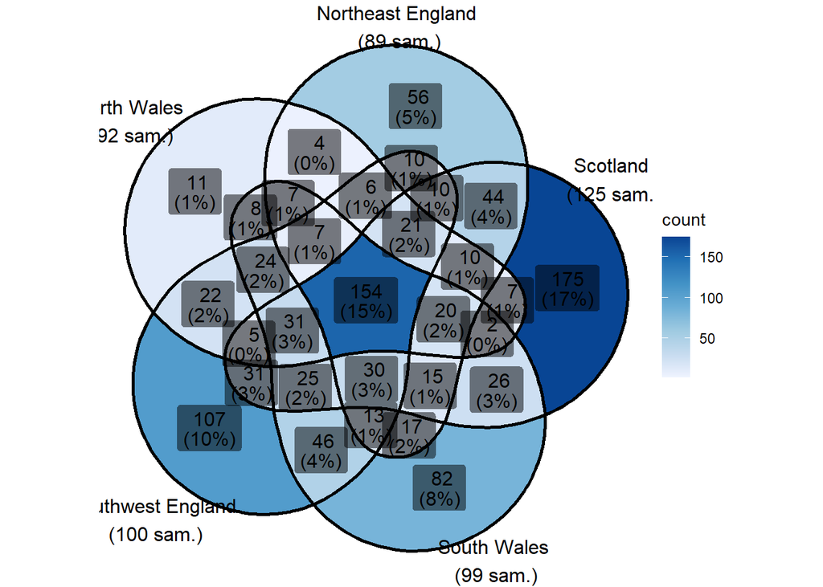

```r
#using another venn function
ggvenn_pq(
  physeq = phylo_rocky_eDNA,
  fact = "country",
  min_nb_seq = 0,
  taxonomic_rank = NULL,
  split_by = NULL,
  add_nb_samples = TRUE,
  add_nb_seq = FALSE,
  rarefy_before_merging = FALSE,
  rarefy_after_merging = FALSE,
  verbose = TRUE,
  type = "nb_taxa",
  na_remove = TRUE
) + ggplot2::scale_fill_distiller(palette = "Blues", direction = 1)
```

#### Summary bar plots

Let’s make some simple visualizing of all taxonomic groups together.

```r
taxonomy_table <- as.data.frame(taxonomy_table)

# Count the number of species for each phylum
kingdom_species_count<- data.table:::setDT(taxonomy_table)[, .(count = data.table:::uniqueN(valid_AphiaID)), by = kingdom]

kingdom_species_count
```

```
     kingdom count
      <char> <int>
1:  Animalia   739
2: Chromista    93
3:   Plantae   194
```

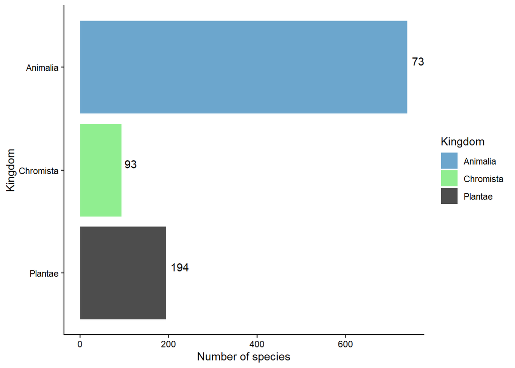

```r
# Plot
taxa_groups_bar_kingdom <- ggplot(data = kingdom_species_count, aes(
  x = count,
  y = forcats::fct_rev(reorder(kingdom, kingdom)),
  fill = kingdom
)) +
  geom_bar(stat = "identity") +
  xlab("Number of species") + ylab("Kingdom") +
  geom_text(
    aes(label = count),
    position = position_dodge(width = 0.9),
    vjust = -0.25,
    hjust = -0.25
  ) +
  scale_fill_manual(
    values = c(
      "skyblue3",
      "lightgreen",
      "grey30",
      "#96E6B3",
      "grey50",
      "#96E6B3",
      "grey50",
      "grey90"
    ),
    name = "Kingdom"
  ) +
  theme_classic()

taxa_groups_bar_kingdom
```

```r
# Count the number of species for each phylum
phylum_species_count<- data.table:::setDT(taxonomy_table)[, .(count = data.table:::uniqueN(valid_AphiaID)), by = phylum]
phylum_species_count
```

```
             phylum count
             <char> <int>
 1:        Mollusca   115
 2:      Arthropoda   156
 3:      Ochrophyta    93
 4: Platyhelminthes    44
 5:      Rhodophyta   171
 6:   Echinodermata    27
 7:        Cnidaria   106
 8:        Annelida   150
 9:         Bryozoa    43
10:        Chordata    21
11:        Nematoda    24
12:    Gastrotricha     7
13:     Chlorophyta    23
14:      Ctenophora     2
15:        Porifera    35
16:    Hemichordata     2
17:       Phoronida     5
18:    Orthonectida     1
19:    Chaetognatha     1
```

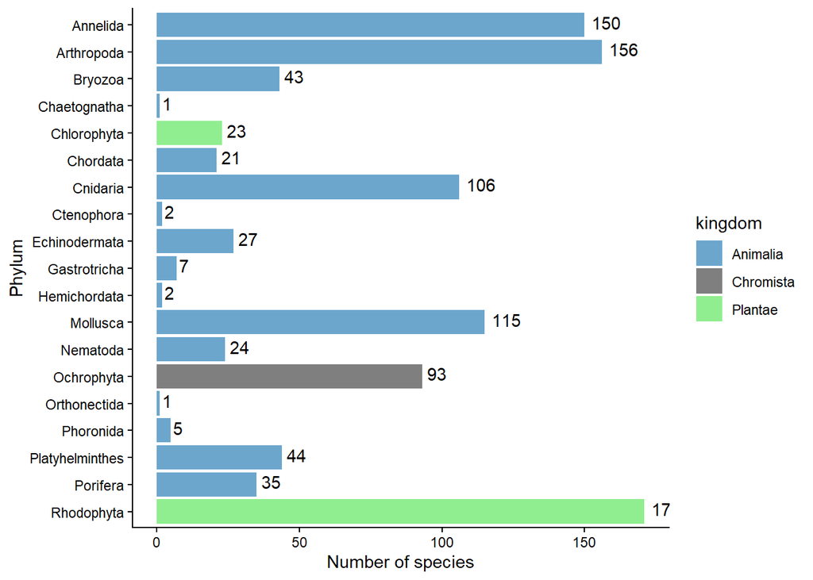

```r
#add kingdom for fill
kingdom_phyla <- taxonomy_table %>%
  dplyr::select(kingdom, phylum)

phylum_species_count <- na.omit(unique(left_join(phylum_species_count, kingdom_phyla)))

# Plot
taxa_groups_bar_phylum <- ggplot(data = phylum_species_count, aes(
  x = count,
  y = forcats::fct_rev(reorder(phylum, phylum)),
  fill = kingdom
)) +
  geom_bar(stat = "identity") +
  xlab("Number of species") + ylab("Phylum") +
  geom_text(
    aes(label = count),
    position = position_dodge(width = 0.9),
    vjust = 0.3,
    hjust = -0.25
  ) +
  scale_fill_manual(values = c(
    "skyblue3",
    "grey50",
    "lightgreen",
    "grey30",
    "#96E6B3",
    "grey20"
  )) +
  theme_classic()

taxa_groups_bar_phylum
```

```r
#count number by functional group
function_species_count <- data.table:::setDT(taxonomy_table)[, .(count = data.table:::uniqueN(valid_AphiaID)), by = .(adult_simple, phylum, kingdom)] %>%
  mutate(adult_simple = ifelse(is.na(adult_simple), "Not found", adult_simple))
function_species_count$phylum = as.factor(function_species_count$phylum)

head(function_species_count)
```

```
   adult_simple          phylum   kingdom count
         <char>          <fctr>    <char> <int>
1: Macrobenthos        Mollusca  Animalia   106
2:        Other      Arthropoda  Animalia    22
3:   Macroalgae      Ochrophyta Chromista    60
4: Macrobenthos Platyhelminthes  Animalia    34
5:   Macroalgae      Rhodophyta   Plantae   136
6: Macrobenthos   Echinodermata  Animalia    27
```

```r
# Group by phylum and adult_simple, and summarize the total count
total_count <- function_species_count %>%
  dplyr::group_by(phylum, adult_simple) %>%  # Grouping by both phylum and simple
  dplyr::summarise(total_count = sum(count, na.rm = TRUE), .groups = 'drop')  # Summarize total count

head(total_count)
```

```
# A tibble: 6 × 3
  phylum     adult_simple total_count
  <fct>      <chr>              <int>
1 Annelida   Macrobenthos         149
2 Annelida   Not found              1
3 Arthropoda Macrobenthos         110
4 Arthropoda Not found             24
5 Arthropoda Other                 22
6 Bryozoa    Macrobenthos          43
```

```r
# Merge total counts with the original data
function_species_count_reduced <- function_species_count %>%
  subset(select = c("phylum", "kingdom")) %>%
  distinct()

function_species_count <- left_join(function_species_count_reduced, total_count, by = "phylum")

head(function_species_count)
```

```
       phylum  kingdom adult_simple total_count
       <fctr>   <char>       <char>       <int>
1:   Mollusca Animalia Macrobenthos         106
2:   Mollusca Animalia    Not found           8
3:   Mollusca Animalia        Other           1
4: Arthropoda Animalia Macrobenthos         110
5: Arthropoda Animalia    Not found          24
6: Arthropoda Animalia        Other          22
```

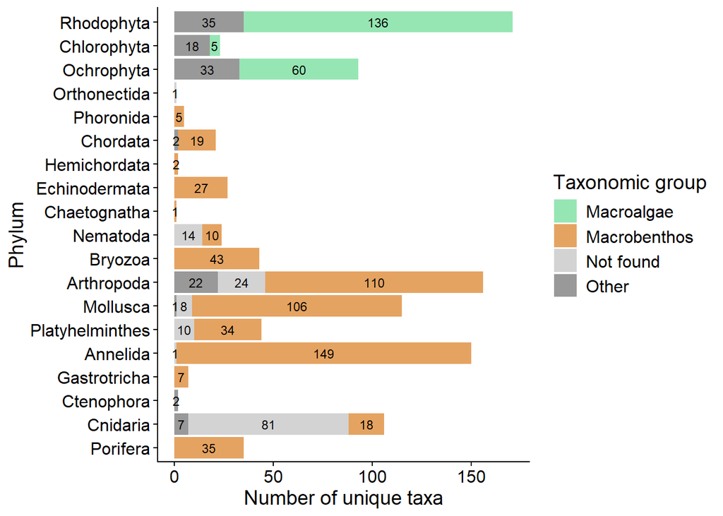

```r
# order of taxa for the plot
taxa_ordered <- c(
  "Porifera",
  "Cnidaria",
  "Ctenophora",
  "Gastrotricha",
  "Annelida",
  "Platyhelminthes",
  "Mollusca",
  "Arthropoda",
  "Bryozoa",
  "Nematoda",
  "Chaetognatha",
  "Echinodermata",
  "Hemichordata",
  "Chordata",
  "Phoronida",
  "Orthonectida",
  "Ochrophyta",
  "Chlorophyta",
  "Rhodophyta"
)

# Create the ggplot with custom color mapping
taxa_groups_bar_phylum_functional <- ggplot(data = function_species_count, aes(x = total_count, y = phylum, fill = adult_simple)) +
  geom_bar(stat = "identity") +
  xlab("Number of unique taxa") +
  ylab("Phylum") +
  scale_fill_manual(values = c("Macroalgae" = "#96E6B3",
                               "Macrobenthos" = "#E5A361",
                               "Other" = "grey60",
                               "Not found" = "lightgrey")) +
  labs(fill = "Taxonomic group") +
  scale_y_discrete(limits = taxa_ordered) +
  geom_text(aes(label = total_count),
            position = position_stack(vjust = 0.5),  # Position text in the center of the bars
            size = 3,  # Adjust size of the text
            color = "black") +  # Change text color for visibility
  theme_classic() +
  theme(
    axis.title.x = element_text(size = 14),  # Make x-axis title slightly bigger
    axis.title.y = element_text(size = 14),  # Make y-axis title slightly bigger
    axis.text.x = element_text(size = 12),   # Make x-axis labels slightly bigger
    axis.text.y = element_text(size = 12),   # Make y-axis labels slightly bigger
    legend.title = element_text(size = 14),  # Make legend title slightly bigger
    legend.text = element_text(size = 12)    # Make legend text slightly bigger
  )


# Print the plot
taxa_groups_bar_phylum_functional
```

```r
# save
ggsave(filename = "Figures/taxa_groups_bar_phylum_98_curated_functional.png", plot = taxa_groups_bar_phylum_functional,
       device = "png", dpi = 600, units = "mm", height = 200, width = 300)
```

## Diversity analyses

Let’s set-up some variables for plotting.

```r
site_order <- c(
  "Scourie",
  "Rispond",
  "Skerray",
  "Murkle Bay",
  "Portskerra",
  "Borwick, Yesnaby",
  "Sannick",
  "Wick",#Scotland
  "Great Orme East",
  "Little Orme",
  "Menai Bridge",
  "Porth Oer",
  "Porth Swtan",
  "Rhosneigr",#North Wales
  "Castlehead Rocks",
  "Filey Brigg",
  "Newton Point",
  "Rumbling Kern",
  "Scalby Mills", #Northumbria
  "Aberystwyth",
  "Neyland",
  "Broad Haven",
  "Skomer Island",
  "West Angle",
  "Monkstone Point",
  "Dale Jetty",
  "Martin's Haven",#South Wales
  "Lizard Point",
  "Looe",
  "Sennen Cove",
  "St Ives",
  "Trevone" #Cornwall
)

control_order <- c(
  "field-control",
  "lab-negative-control",
  "lab-positive-control",
  "sample",
  "replicate",
  "failed-repeat",
  "stageone-repeat"
)

country_order <- c("Scotland",
                   "Northeast England",
                   "North Wales",
                   "South Wales",
                   "Southwest England")

shore_height_order <- c("High", "Low", "Open Water")
```

### Rarefaction curves

Rarefaction curves are used to check if our read depths look suitable enough to capture all diversity present in the samples. We make a curve for each region and primer.

Scotland

```r
# CO1
SCH_phylo_CO1 <- subset_samples(phylo_rocky_eDNA, country == "Scotland" & primer == 'CO1')
asv_abund_df_SCH_CO1 <- as.data.frame(t(phyloseq::otu_table(SCH_phylo_CO1)))
raremax <- min(rowSums(asv_abund_df_SCH_CO1))
raremax
```

```
[1] 0
```

```r
# Create tidy output
out_SCH_CO1 <- vegan::rarecurve(
  x = asv_abund_df_SCH_CO1,
  step = 20,
  xlab = "Read depth", ylab = "Taxa",
  lwd = 1,
  label = F,
  tidy = T,
  sample = raremax)

# Plot
SCH_CO1_curve <- ggplot(data = out_SCH_CO1, mapping = aes(x = Sample, y = Species, group = Site)) +
  geom_line(color = "#E5A361") +
  xlab("Read depth") + ylab("Taxa") +
  #ggtitle("Rarefaction curve for Scotland CO1 samples")+
  geom_vline(xintercept =raremax, linetype="dashed") +
  theme_classic()

# 18S
SCH_phylo_18S <- subset_samples(phylo_rocky_eDNA, country == "Scotland" & primer == '18S')
asv_abund_df_SCH_18S <- as.data.frame(t(phyloseq::otu_table(SCH_phylo_18S)))
raremax <- min(rowSums(asv_abund_df_SCH_18S))
raremax
```

```
[1] 69
```

```r
# Create tidy output
out_SCH_18S <- vegan::rarecurve(
  x = asv_abund_df_SCH_18S,
  step = 20,
  xlab = "Read depth", ylab = "Taxa",
  lwd = 1,
  label = F,
  tidy = T,
  sample = raremax)

# Plot
SCH_18S_curve <- ggplot(data = out_SCH_18S, mapping = aes(x = Sample, y = Species, group = Site)) +
  geom_line(color = "green3") +
  xlab("Read depth") + ylab("Taxa") +
  #ggtitle("Rarefaction curve for Scotland 18S samples")+
  geom_vline(xintercept =raremax, linetype="dashed") +
  theme_classic()
```

South Wales

```r
#CO1
SW_phylo_CO1 <- subset_samples(phylo_rocky_eDNA, country == "South Wales" & primer == 'CO1')
asv_abund_df_SW_CO1 <- as.data.frame(t(phyloseq::otu_table(SW_phylo_CO1)))
raremax <- min(rowSums(asv_abund_df_SW_CO1))
raremax
```

```
[1] 165
```

```r
#Create tidy output
out_SW_CO1 <- vegan::rarecurve(
  x = asv_abund_df_SW_CO1,
  step = 20,
  xlab = "Read depth", ylab = "Taxa",
  lwd = 1,
  label = F,
  tidy = T,
  sample = raremax)

#Plot
SW_CO1_curve <- ggplot(data = out_SW_CO1, mapping = aes(x = Sample, y = Species, group = Site)) +
  geom_line(color = "#E5A361") +
  xlab("Read depth") + ylab("Taxa") +
  #ggtitle("Rarefaction curve for South Wales CO1 samples")+
  geom_vline(xintercept =raremax, linetype="dashed") +
  theme_classic()

#18S
SW_phylo_18S <- subset_samples(phylo_rocky_eDNA, country == "South Wales" & primer == '18S')
asv_abund_df_SW_18S <- as.data.frame(t(phyloseq::otu_table(SW_phylo_18S)))
raremax <- min(rowSums(asv_abund_df_SW_18S))
raremax
```

```
[1] 402
```

```r
#Create tidy output
out_SW_18S <- vegan::rarecurve(
  x = asv_abund_df_SW_18S,
  step = 20,
  xlab = "Read depth", ylab = "Taxa",
  lwd = 1,
  label = F,
  tidy = T,
  sample = raremax)

#Plot
SW_18S_curve <- ggplot(data = out_SW_18S, mapping = aes(x = Sample, y = Species, group = Site)) +
  geom_line(color = "green3") +
  xlab("Read depth") + ylab("Taxa") +
  #ggtitle("Rarefaction curve for South Wales 18S samples")+
  geom_vline(xintercept =raremax, linetype="dashed") +
  theme_classic()
```

Cornwall

```r
#CO1
CN_phylo_CO1 <- subset_samples(phylo_rocky_eDNA, country == "Southwest England" & primer == 'CO1')
asv_abund_df_CN_CO1 <- as.data.frame(t(phyloseq::otu_table(CN_phylo_CO1)))
raremax <- min(rowSums(asv_abund_df_CN_CO1))
raremax
```

```
[1] 93
```

```r
#Create tidy output
out_CN_CO1 <- vegan::rarecurve(
  x = asv_abund_df_CN_CO1,
  step = 20,
  xlab = "Read depth", ylab = "Taxa",
  lwd = 1,
  label = F,
  tidy = T,
  sample = raremax)

#Plot
CN_CO1_curve <- ggplot(data = out_CN_CO1, mapping = aes(x = Sample, y = Species, group = Site)) +
  geom_line(color = "#E5A361") +
  xlab("Read depth") + ylab("Taxa") +
  #ggtitle("Rarefaction curve for Cornwall CO1 samples")+
  geom_vline(xintercept =raremax, linetype="dashed") +
  theme_classic()

#18S
CN_phylo_18S <- subset_samples(phylo_rocky_eDNA, country == "Southwest England" & primer == '18S')
asv_abund_df_CN_18S <- as.data.frame(t(phyloseq::otu_table(CN_phylo_18S)))
raremax <- min(rowSums(asv_abund_df_CN_18S))
raremax
```

```
[1] 45
```

```r
#Create tidy output
out_CN_18S <- vegan::rarecurve(
  x = asv_abund_df_CN_18S,
  step = 20,
  xlab = "Read depth", ylab = "Taxa",
  lwd = 1,
  label = F,
  tidy = T,
  sample = raremax)

#Plot
CN_18S_curve <- ggplot(data = out_CN_18S, mapping = aes(x = Sample, y = Species, group = Site)) +
  geom_line(color = "green3") +
  xlab("Read depth") + ylab("Taxa") +
  #ggtitle("Rarefaction curve for Cornwall 18S samples")+
  geom_vline(xintercept =raremax, linetype="dashed") +
  theme_classic()
```

Northeast England

```r
#CO1
NE_phylo_CO1 <- subset_samples(phylo_rocky_eDNA, country == "Northeast England" & primer == 'CO1')
asv_abund_df_NE_CO1 <- as.data.frame(t(phyloseq::otu_table(NE_phylo_CO1)))
raremax <- min(rowSums(asv_abund_df_NE_CO1))
raremax
```

```
[1] 94
```

```r
#Create tidy output
out_NE_CO1 <- vegan::rarecurve(
  x = asv_abund_df_NE_CO1,
  step = 20,
  xlab = "Read depth", ylab = "Taxa",
  lwd = 1,
  label = F,
  tidy = T,
  sample = raremax)

#Plot
NE_CO1_curve <- ggplot(data = out_NE_CO1, mapping = aes(x = Sample, y = Species, group = Site)) +
  geom_line(color = "#E5A361") +
  xlab("Read depth") + ylab("Taxa") +
  #ggtitle("Rarefaction curve for Northeast CO1 samples")+
  geom_vline(xintercept =raremax, linetype="dashed") +
  theme_classic()

#18S
NE_phylo_18S <- subset_samples(phylo_rocky_eDNA, country == "Northeast England" & primer == '18S')
asv_abund_df_NE_18S <- as.data.frame(t(phyloseq::otu_table(NE_phylo_18S)))
raremax <- min(rowSums(asv_abund_df_NE_18S))
raremax
```

```
[1] 1646
```

```r
#Create tidy output
out_NE_18S <- vegan::rarecurve(
  x = asv_abund_df_NE_18S,
  step = 20,
  xlab = "Read depth", ylab = "Taxa",
  lwd = 1,
  label = F,
  tidy = T,
  sample = raremax)

#Plot
NE_18S_curve <- ggplot(data = out_NE_18S, mapping = aes(x = Sample, y = Species, group = Site)) +
  geom_line(color = "green3") +
  xlab("Read depth") + ylab("Taxa") +
  #ggtitle("Rarefaction curve for Northeast 18S samples")+
  geom_vline(xintercept =raremax, linetype="dashed") +
  theme_classic()
```

North Wales

```r
#CO1
NW_phylo_CO1 <- subset_samples(phylo_rocky_eDNA, country == "North Wales" & primer == 'CO1')
asv_abund_df_NW_CO1 <- as.data.frame(t(phyloseq::otu_table(NW_phylo_CO1)))
raremax <- min(rowSums(asv_abund_df_NW_CO1))
raremax
```

```
[1] 145
```

```r
#Create tidy output
out_NW_CO1 <- vegan::rarecurve(
  x = asv_abund_df_NW_CO1,
  step = 20,
  xlab = "Read depth", ylab = "Taxa",
  lwd = 1,
  label = F,
  tidy = T,
  sample = raremax)

#Plot
NW_CO1_curve <- ggplot(data = out_NW_CO1, mapping = aes(x = Sample, y = Species, group = Site)) +
  geom_line(color = "#E5A361") +
  xlab("Read depth") + ylab("Taxa") +
  #ggtitle("Rarefaction curve for North Wales CO1 samples")+
  geom_vline(xintercept =raremax, linetype="dashed") +
  theme_classic()

#18S
NW_phylo_18S <- subset_samples(phylo_rocky_eDNA, country == "North Wales" & primer == '18S')
asv_abund_df_NW_18S <- as.data.frame(t(phyloseq::otu_table(NW_phylo_18S)))
raremax <- min(rowSums(asv_abund_df_NW_18S))
raremax
```

```
[1] 6
```

```r
#Create tidy output
out_NW_18S <- vegan::rarecurve(
  x = asv_abund_df_NW_18S,
  step = 20,
  xlab = "Read depth", ylab = "Taxa",
  lwd = 1,
  label = F,
  tidy = T,
  sample = raremax)

#Plot
NW_18S_curve <- ggplot(data = out_NW_18S, mapping = aes(x = Sample, y = Species, group = Site)) +
  geom_line(color = "green3") +
  xlab("Read depth") + ylab("Taxa") +
  #ggtitle("Rarefaction curve for North Wales 18S samples")+
  geom_vline(xintercept =raremax, linetype="dashed") +
  theme_classic()
```

Plot all together.

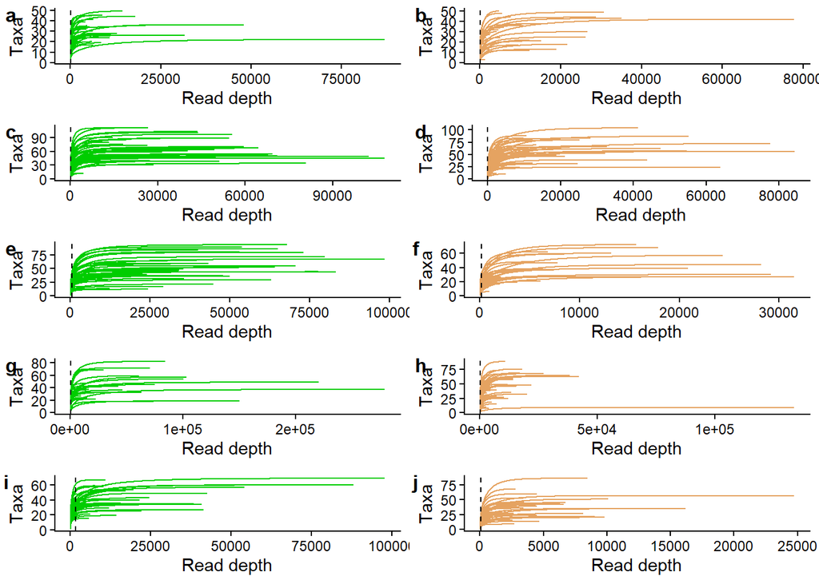

```r
curves_all <- cowplot::plot_grid(NW_18S_curve,
          NW_CO1_curve,
          SCH_18S_curve,
          SCH_CO1_curve,
          SW_18S_curve,
          SW_CO1_curve,
          CN_18S_curve,
          CN_CO1_curve,
          NE_18S_curve,
          NE_CO1_curve, labels = c('a', 'b', 'c', 'd', 'e', 'f', 'g', 'h', 'i', 'j'), label_size = 12, ncol = 2)

curves_all
```

```r
ggsave(filename = "Figures/rarefaction_curve_all.png", plot = curves_all,
       device = "png", dpi = 600, units = "mm", height = 450, width = 300)
```

### Alpha diversity

We tested if alpha diversity differed across shore heights through a mixed modelling approach.

```r
alpha_df <- phyloseq::estimate_richness(physeq = phylo_rocky_eDNA, measure = c("Observed", "Shannon"))

head(alpha_df)
```

```
                  Observed   Shannon
PHD1.SCH01.01_18S       80 2.6468538
PHD1.SCH01.01_CO1       45 0.8374963
PHD1.SCH01.02_18S      111 3.7567788
PHD1.SCH01.02_CO1       70 3.0690689
PHD1.SCH01.03_18S       90 3.4621410
PHD1.SCH01.03_CO1       42 3.3142165
```

```r
# Add diversity metrics to sample data
diversity_meta <- cbind(meta_target, alpha_df)
diversity_meta$shorePosition <- as.factor(diversity_meta$shorePosition)
diversity_meta$verbatimLocality <- as.factor(diversity_meta$verbatimLocality)
diversity_meta <- diversity_meta[!is.na(diversity_meta$shorePosition), ]
diversity_meta <- diversity_meta[!is.na(diversity_meta$country), ]
diversity_meta <- diversity_meta[!is.na(diversity_meta$verbatimLocality), ]
diversity_meta <- diversity_meta[!is.na(diversity_meta$averageTemp), ]
diversity_meta <- diversity_meta[!is.na(diversity_meta$averagePH), ]
```

#### Visualize data

Let’s check the distributions of our raw data.

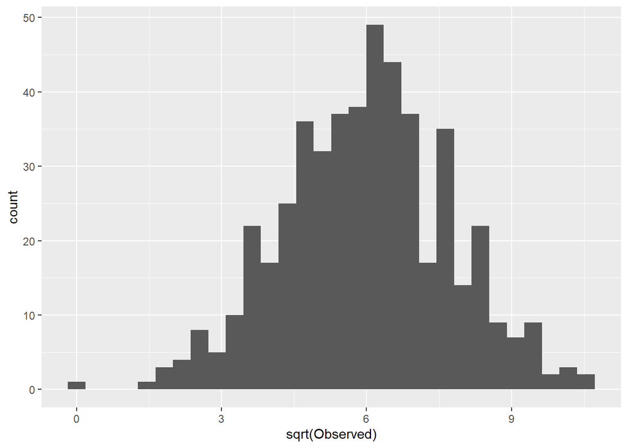

```r
#response
ggplot(diversity_meta, aes(x=sqrt(Observed))) + geom_histogram()
```

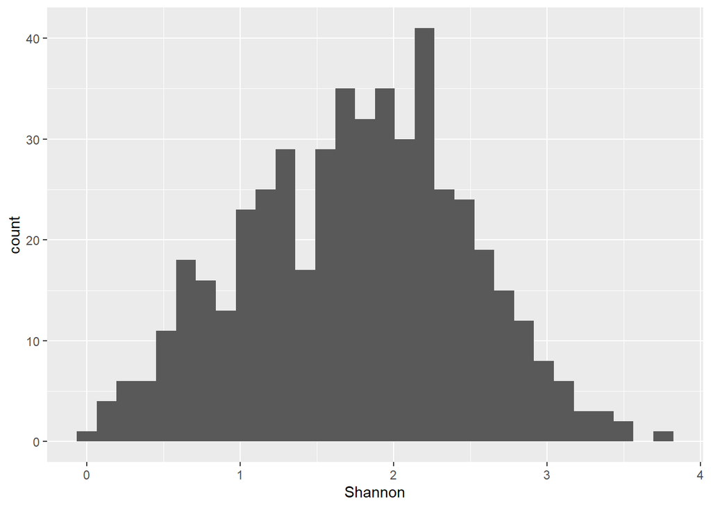

```r
ggplot(diversity_meta, aes(x=Shannon)) + geom_histogram()
```

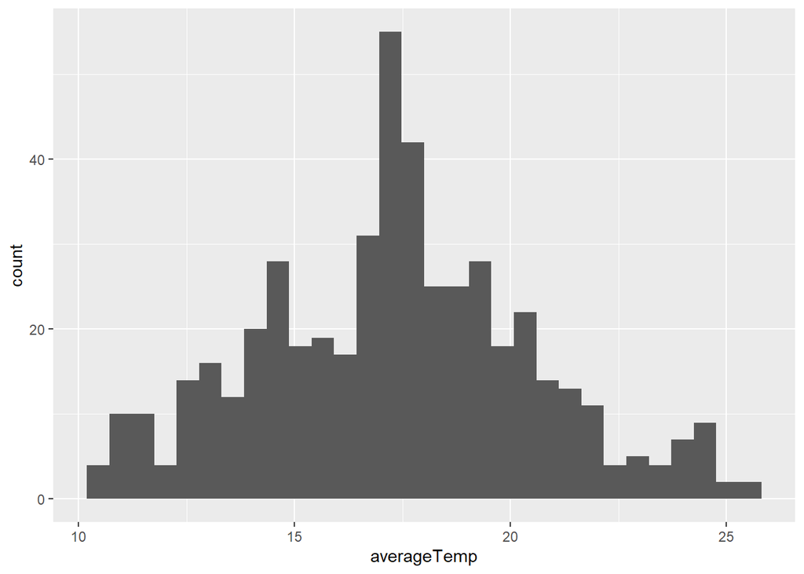

```r
#predictors
ggplot(diversity_meta, aes(x=averageTemp)) + geom_histogram()
```

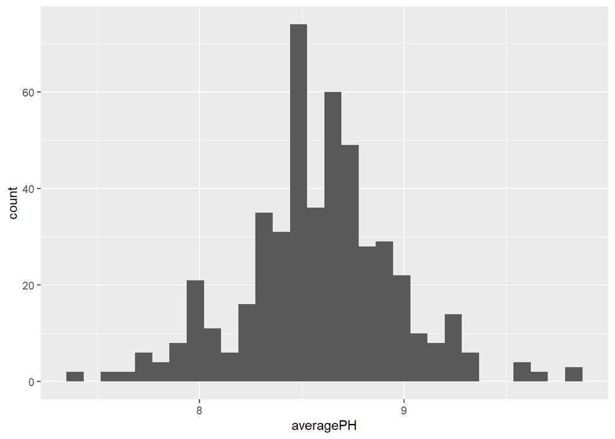

```r
ggplot(diversity_meta, aes(x=averagePH)) + geom_histogram()
```

```r
diversity_meta_summary <- diversity_meta %>%
  dplyr::group_by(shorePosition) %>%
  dplyr::summarise(mean = mean(averageTemp),
                   SE = sd(averageTemp) / sqrt(n()))

head(diversity_meta_summary)
```

```
# A tibble: 3 × 3
  shorePosition  mean    SE
  <fct>         <dbl> <dbl>
1 High           17.9 0.286
2 Low            17.6 0.272
3 Open Water     16.7 0.201
```

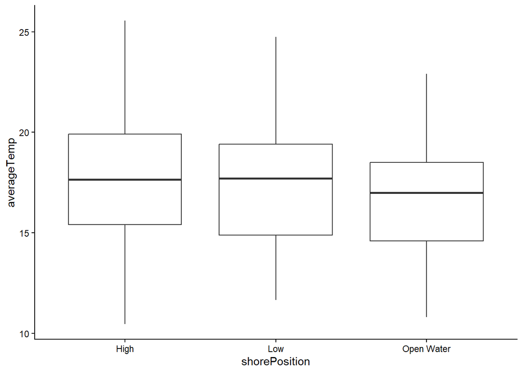

```r
ggplot(diversity_meta, aes(x = shorePosition, y = averageTemp)) +
  geom_boxplot() +
  theme_classic()
```

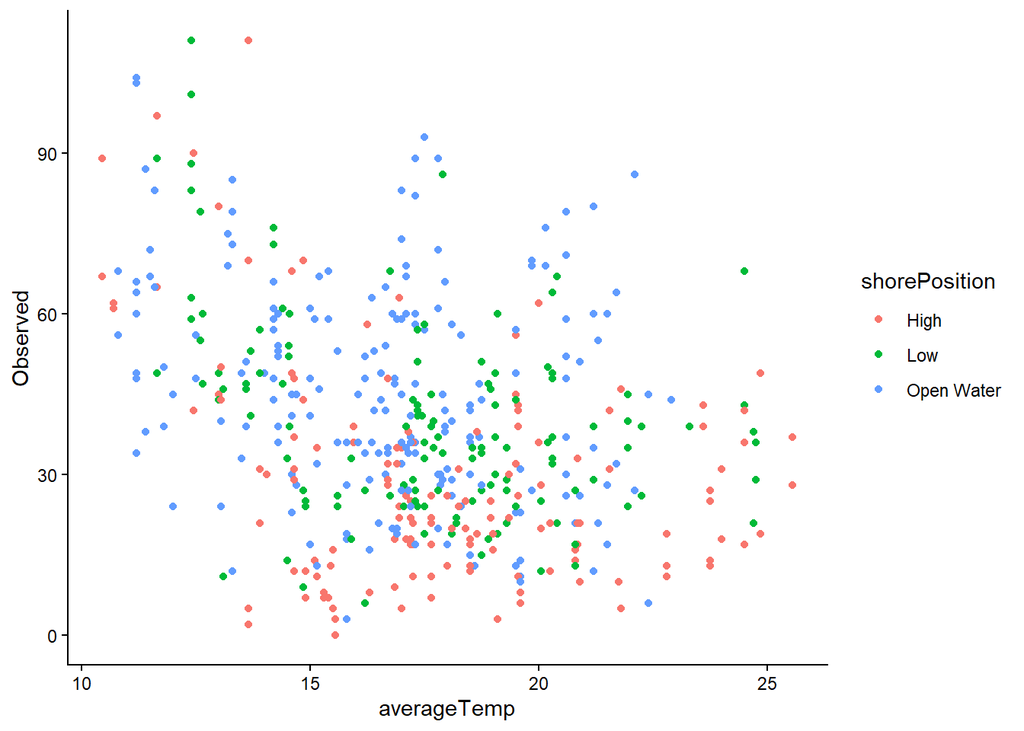

```r
# richness vs temp
diversity_temp_scatter <- ggplot(diversity_meta,
                                 aes(x = averageTemp, y = Observed, colour = shorePosition)) +
  geom_point() +
  theme_classic()

diversity_temp_scatter
```

```r
# shannon vs temp
diversity_temp_scatter <- ggplot(diversity_meta, aes(x = averageTemp, y = Shannon)) +
  geom_point() +
  theme_classic()
```

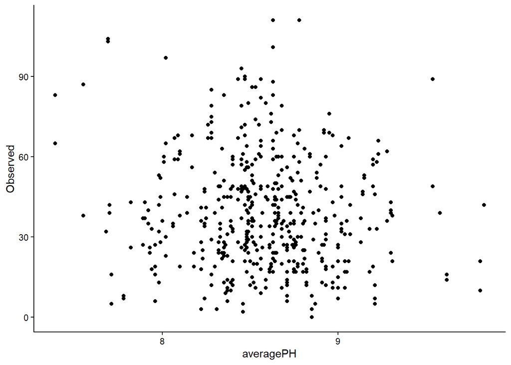

```r
# richness vs pH
diversity_pH_scatter <- ggplot(diversity_meta, aes(x = averagePH, y = Observed)) +
  geom_point() +
  theme_classic()

diversity_pH_scatter #no pattern observed
```

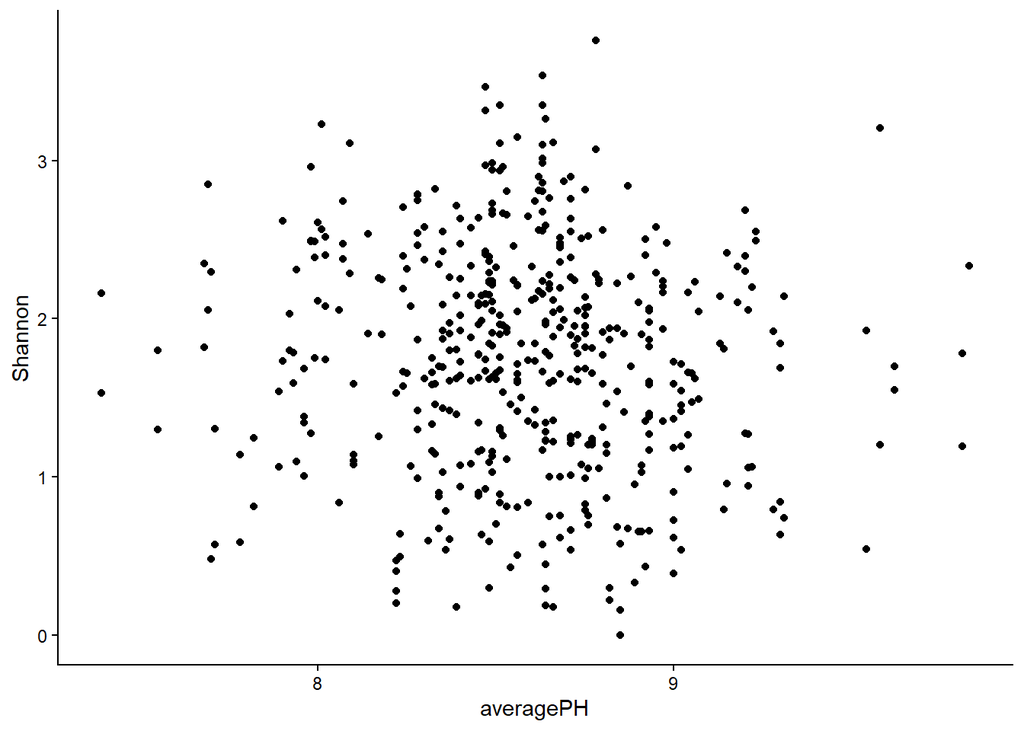

```r
# shannon vs pH
diversity_pH_scatter <- ggplot(diversity_meta, aes(x = averagePH, y = Shannon)) +
  geom_point() +
  theme_classic()

diversity_pH_scatter #no pattern observed
```

#### Mixed models

```r
# construct model
richness_mod <- glmer(
  Observed ~ country + shorePosition + averageTemp + averagePH +
    (1 | country:verbatimLocality),
  data = diversity_meta,
  family = poisson,
  control = glmerControl(optimizer = "bobyqa")
)

#outputs
summary(richness_mod)
```

```
Generalized linear mixed model fit by maximum likelihood (Laplace
  Approximation) [glmerMod]
 Family: poisson  ( log )
Formula: Observed ~ country + shorePosition + averageTemp + averagePH +
    (1 | country:verbatimLocality)
   Data: diversity_meta
Control: glmerControl(optimizer = "bobyqa")

      AIC       BIC    logLik -2*log(L)  df.resid
   5352.7    5394.7   -2666.4    5332.7       479

Scaled residuals:
    Min      1Q  Median      3Q     Max
-6.5695 -1.6156 -0.1847  1.3447 10.9377

Random effects:
 Groups                   Name        Variance Std.Dev.
 country:verbatimLocality (Intercept) 0.07151  0.2674
Number of obs: 489, groups:  country:verbatimLocality, 32

Fixed effects:
                          Estimate Std. Error z value Pr(>|z|)
(Intercept)               5.478396   0.299321  18.303  < 2e-16 ***
countryNortheast England  0.219179   0.164574   1.332  0.18293
countryScotland           0.308451   0.151586   2.035  0.04187 *
countrySouth Wales        0.601235   0.149353   4.026 5.68e-05 ***
countrySouthwest England  0.566849   0.164749   3.441  0.00058 ***
shorePositionLow          0.264683   0.021650  12.226  < 2e-16 ***
shorePositionOpen Water   0.297941   0.022796  13.070  < 2e-16 ***
averageTemp              -0.080860   0.008423  -9.600  < 2e-16 ***
averagePH                -0.120844   0.032808  -3.683  0.00023 ***
---
Signif. codes:  0 '***' 0.001 '**' 0.01 '*' 0.05 '.' 0.1 ' ' 1

Correlation of Fixed Effects:
            (Intr) cntrNE cntryS cntrSW cntrSE shrPsL shrPOW avrgTm
cntryNrthsE -0.250
cntrySctlnd -0.298  0.506
cntrySthWls -0.191  0.498  0.511
cntrySthwsE -0.177  0.457  0.491  0.512
shorePstnLw -0.186 -0.007  0.039 -0.037 -0.025
shrPstnOpnW -0.395  0.015  0.085 -0.100 -0.033  0.596
averageTemp -0.253  0.038  0.247 -0.154 -0.034  0.174  0.402
averagePH   -0.786 -0.023 -0.109 -0.007 -0.061  0.066  0.162 -0.280
```

```r
anova(richness_mod)
```

```
Analysis of Variance Table
              npar Sum Sq Mean Sq  F value
country          4  19.80   4.950   4.9503
shorePosition    2 476.84 238.421 238.4206
averageTemp      1 123.70 123.695 123.6953
averagePH        1  13.57  13.566  13.5662
```

```r
Anova(richness_mod, type = "II")
```

```
Analysis of Deviance Table (Type II Wald chisquare tests)

Response: Observed
                Chisq Df Pr(>Chisq)
country        20.413  4  0.0004138 ***
shorePosition 201.352  2  < 2.2e-16 ***
averageTemp    92.157  1  < 2.2e-16 ***
averagePH      13.567  1  0.0002302 ***
---
Signif. codes:  0 '***' 0.001 '**' 0.01 '*' 0.05 '.' 0.1 ' ' 1
```

```r
# get p-values
beta_hat <- fixef(richness_mod)  # Estimated coefficients
se_beta <- sqrt(diag(vcov(richness_mod)))  # Standard errors of the coefficients
t_values <- beta_hat / se_beta # Calculate Wald t-values manually
p_values <- 2 * (1 - pnorm(abs(t_values)))  # Two-tailed test
p_values
```

```
             (Intercept) countryNortheast England          countryScotland
            0.000000e+00             1.829267e-01             4.186879e-02
      countrySouth Wales countrySouthwest England         shorePositionLow
            5.683271e-05             5.802647e-04             0.000000e+00
 shorePositionOpen Water              averageTemp                averagePH
            0.000000e+00             0.000000e+00             2.301840e-04
```

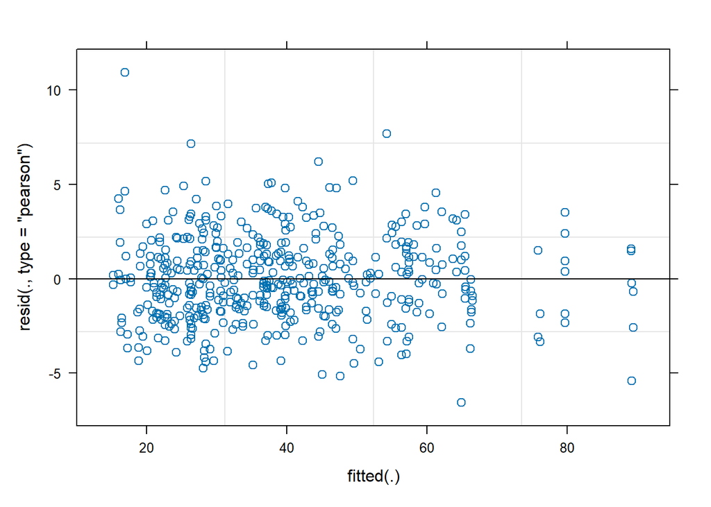

```r
plot(richness_mod) #good
```

```r
ranef(richness_mod)
```

```
$`country:verbatimLocality`
                                   (Intercept)
North Wales:Great Orme East         0.36423398
North Wales:Little Orme             0.01310313
North Wales:Menai Bridge           -0.16951800
North Wales:Porth Oer               0.14969974
North Wales:Porth Swtan             0.15082710
North Wales:Rhosneigr              -0.50083253
Northeast England:Castlehead Rocks  0.06556076
Northeast England:Filey Brigg       0.15876477
Northeast England:Newton Point     -0.14915955
Northeast England:Rumbling Kern    -0.38112416
Northeast England:Scalby Mills      0.31002725
Scotland:Borwick, Yesnaby           0.23991335
Scotland:Murkle Bay                -0.15238778
Scotland:Portskerra                 0.16470149
Scotland:Rispond                   -0.52190894
Scotland:Sannick                   -0.09395340
Scotland:Scourie                    0.37257815
Scotland:Skerray                    0.14587388
Scotland:Wick                      -0.14841522
South Wales:Aberystwyth             0.34155831
South Wales:Broad Haven            -0.51026115
South Wales:Dale Jetty             -0.18621732
South Wales:Martin's Haven          0.23963579
South Wales:Monkstone Point        -0.16642239
South Wales:Neyland                 0.21484691
South Wales:Skomer Island           0.04933249
South Wales:West Angle              0.02842227
Southwest England:Lizard Point     -0.39522669
Southwest England:Looe             -0.06799309
Southwest England:Sennen Cove      -0.09716852
Southwest England:St Ives           0.17921484
Southwest England:Trevone           0.38453579

with conditional variances for "country:verbatimLocality"
```

```r
vif(richness_mod)
```

```
                  GVIF Df GVIF^(1/(2*Df))
country       1.220544  4        1.025225
shorePosition 1.343198  2        1.076552
averageTemp   1.614611  1        1.270673
averagePH     1.216202  1        1.102815
```